# R Notebook

## Exercise 2, Chapter 6

The dataset melanoma gives data on a sample of patients suffering from melanoma (skin cancer) cross-classified by the type of cancer and the location on the body.

```r
suppressMessages(library(faraway)); data(melanoma)
summary(melanoma)
```

```
     count                  tumor          site
 Min.   :  2.00   freckle      :3   extremity:4
 1st Qu.: 14.75   indeterminate:3   head     :4
 Median : 20.50   nodular      :3   trunk    :4
 Mean   : 33.33   superficial  :3
 3rd Qu.: 38.25
 Max.   :115.00
```

```r
head(melanoma)
```

|  | count | tumor | site |
| --- | --- | --- | --- |
| 1 | 22 | freckle | head |
| 2 | 16 | superficial | head |
| 3 | 19 | nodular | head |
| 4 | 11 | indeterminate | head |
| 5 | 2 | freckle | trunk |
| 6 | 54 | superficial | trunk |

1. Display the data in a two-way table. Make a mosaic plot and comment on the evidence for independence.

```r
yep <- xtabs(formula = count ~ tumor + site, data = melanoma)
yep
```

```
               site
tumor           extremity head trunk
  freckle              10   22     2
  indeterminate        28   11    17
  nodular              73   19    33
  superficial         115   16    54
```

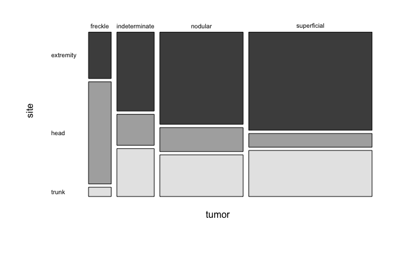

```r
mosaicplot(yep, color=TRUE, main=NULL, las=1 )
```

It appears as though extremity increases and trunk increases as tumer goes from frackle to superficial. It does not appear that this these variables are independent.

2. Check for independence between site and tumor type using a Chi-squared test.

```r
summary(yep)
```

```
Call: xtabs(formula = count ~ tumor + site, data = melanoma)
Number of cases in table: 400
Number of factors: 2
Test for independence of all factors:
    Chisq = 65.81, df = 6, p-value = 2.943e-12
```

Since the p-value for the chi-squared test is <0.05, we will reject the null hypothesis that there site and tumor are independent

3. Fit a Poisson GLM model and use it to check for independence.

```r
mods <- glm(count ~ tumor + site, data = melanoma, family=poisson)
pchisq(deviance(mods),df.residual(mods),lower=F)
```

```
[1] 2.050453e-09
```

4. Make a two-way table of the deviance residuals from the last model. Comment on the larger residuals.

```r
xtabs(residuals(mods) ~ tumor + site, data = melanoma)
```

```
               site
tumor             extremity        head       trunk
  freckle       -2.31583297  5.13537787 -2.82829426
  indeterminate -0.66016102  0.46798432  0.54787007
  nodular        0.28104581 -0.49711084 -0.02173229
  superficial    1.00813975 -3.04533605  0.69899703
```

## Exercise 10, Chapter 6

The UCB Admissions dataset presents data on applicants to graduate school at Berkeley for the six largest departments in 1973 classified by admission and sex.

1. 1. Show that this provides an example of Simpson’s paradox.

```r
require(graphics)
## Data aggregated over departments
apply(UCBAdmissions, c(1, 2), sum)
```

```
          Gender
Admit      Male Female
  Admitted 1198    557
  Rejected 1493   1278
```

```r
## Data for individual departments
opar <- par(mfrow = c(2, 3), oma = c(0, 0, 2, 0))
for(i in 1:6)
  mosaicplot(UCBAdmissions[,,i],
    xlab = "Admit", ylab = "Sex",
    main = paste("Department", LETTERS[i]))
mtext(expression(bold("Student admissions at UC Berkeley")),
      outer = TRUE, cex = 1.5)
```

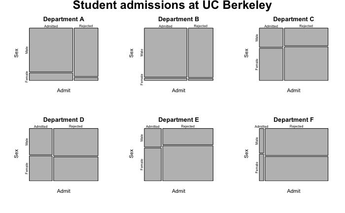

```r
par(opar)
```

FROM rdrr.io “There were 2691 male applicants, of whom 1198 (44.5%) were admitted, compared with 1835 female applicants of whom 557 (30.4%) were admitted. This gives a sample odds ratio of 1.83, indicating that males were almost twice as likely to be admitted. In fact, graphical methods (as in the example below) or log-linear modelling show that the apparent association between admission and sex stems from differences in the tendency of males and females to apply to the individual departments (females used to apply more to departments with higher rejection rates).”

From a quick look at the over all data, it appears that women are more likely to be rejected than men. But when we partition the data by departmentand look at the gender vs. admit breakdowns, its clear that female students are applying to less of the departments with higher acceptance rates (ie, Dept A) and more of the departments with higher rejection rates (ie, Dept F or C).

2. 2. Determine the most appropriate dependence model between the variables.

```r
## ====================================
# Model Selection
ucb_df <- data.frame(UCBAdmissions)

modsat <- glm(Freq ~ Gender*Dept*Admit, ucb_df, family=poisson) # Most complicated

modu <- glm(Freq ~ (Gender+Dept+Admit)^2, ucb_df, family=poisson) # Simpler than above

1 - pchisq(q=(deviance(modu)- deviance(modsat)), df=(length(coef(modsat)) - length(coef(modu))))
```

```
[1] 0.001144078
```

3. 3. Fit a binomial regression with admissions status as the response and show the relationship to your model in the previous question.

```r
## Convert to dataframe & sort
ucb_df <- ucb_df[order(ucb_df$Admit),]
y_bin <- matrix(ucb_df$Freq,ncol=2) #First column is accepted, second column is rejected
portion <- ucb_df[1:12,]

modbin <- glm(y_bin ~ (Gender+Dept)^2, portion, family=binomial)

modbin
```

```
Call:  glm(formula = y_bin ~ (Gender + Dept)^2, family = binomial, data = portion)

Coefficients:
       (Intercept)        GenderFemale               DeptB               DeptC               DeptD
           0.49212             1.05208             0.04163            -1.02764            -1.19608
             DeptE               DeptF  GenderFemale:DeptB  GenderFemale:DeptC  GenderFemale:DeptD
          -1.44908            -3.26187            -0.83205            -1.17700            -0.97009
GenderFemale:DeptE  GenderFemale:DeptF
          -1.25226            -0.86318

Degrees of Freedom: 11 Total (i.e. Null);  0 Residual
Null Deviance:      877.1
Residual Deviance: 1.159e-13    AIC: 92.94
```